# SAHAM META 2022-2023

Indra Maulana

2023-10-24

```r
theme.ts <- list(
  theme(legend.position = "none",
        axis.text.x = element_text(hjust = 1,
                                   margin = margin(b = 10, t=20)),
        axis.text.y = element_text(vjust = 0.5, face = "bold",
                                   margin = margin(l = 20, r = 20)),
        plot.title = element_text(hjust = 0.5, face = "bold"),
        text = element_text(size = 30),
        plot.subtitle = element_text(hjust = 0.5),
        panel.background = element_rect(fill = 'transparent'),
        plot.background = element_rect(fill='transparent', color=NA),
        panel.grid.major = element_blank(),
        panel.grid.minor = element_blank(),
        axis.line = element_line(linewidth = 1, colour = "black"))
        )
theme <- list(
  theme(legend.position = "none",
        axis.text.x = element_text(hjust = 1,
                                   margin = margin(b = 10, t=20)),
        axis.text.y = element_text(vjust = 0.5, face = "bold",
                                   margin = margin(l = 50, r = 20)),
        plot.title = element_text(hjust = 0.5, face = "bold"),
        text = element_text(size = 30),
        plot.subtitle = element_text(hjust = 0.5),
        panel.background = element_rect(fill = 'transparent'),
        plot.background = element_rect(fill='transparent', color=NA),
        panel.grid.major = element_blank(),
        panel.grid.minor = element_blank(),
        axis.line = element_line(linewidth = 1, colour = "black"))
        )
```

```r
model1 <- function(data, p_max, d, q_max, alpha=0.05) {
  best_model <- NULL
  best_aic <- Inf
  eacf_result <- eacf(data)
  models <- data.frame(Model = character(0),
                       AIC = numeric(0),
                       Signif = character(0),
                       Keterangan = character(0))

  for (p in 0:p_max) {
    for (q in 1:q_max) {
      #Pola Matriks segitiga bawah
      if (!is.na(eacf_result$symbol[p + 1, q + 1]) &&
          !is.na(eacf_result$symbol[p + 1, q + 2]) &&
          !is.na(eacf_result$symbol[p + 2, q + 2])) {
        if (eacf_result$symbol[p + 1, q + 1] == "o" &&
            eacf_result$symbol[p + 1, q + 2] == "o" &&
            eacf_result$symbol[p + 2, q + 2] == "o") {

          model <- Arima(data, order = c(p, d, q), method = "ML")
          aic <- AIC(model)

          # Mendapatkan nilai coef dari model
          coeftest_result <- lmtest::coeftest(model)

          # jika lebih kecil dari alpha, maka signifikan
          significant_params <-
            rownames(coeftest_result)[coeftest_result[, "Pr(>|z|)"] < alpha]

          # jika lebih besar dari alpha, maka tidak signifikan
          non_significant_params <-
            rownames(coeftest_result)[coeftest_result[, "Pr(>|z|)"] > alpha]

          # Keterangan signifikansi
          if (length(significant_params) == 0) {
            keterangan <- "Semua parameter tidak signifikan"
          } else if (length(significant_params) == nrow(coeftest_result)) {
            keterangan <- "Semua parameter signifikan"
          } else {
            keterangan <- paste("Parameter yang tidak signifikan adalah",
                                paste(non_significant_params, collapse = ", "))
          }

          models <- rbind(models,
                    data.frame(Model = paste("ARIMA(", p, ",", d, ",", q, ")",
                                             sep = ""),
                               AIC = aic,
                               Signif = paste(significant_params,
                                              collapse = ", "),
                               Keterangan = keterangan))

          #Identifikasi Best Model
            if (keterangan == "Semua parameter signifikan" &&
                !any(is.na(significant_params))) {
              if (aic < best_aic) {
                best_model <- model
                best_aic <- aic
            }
          }
        }
      }
    }
  }

  cat("\nModel ARIMA dengan AIC terkecil:\n")
  print(best_model)

  return(models)
}

# model dengan drift
model2 <- function(data, p_max, d, q_max, alpha=0.05) {
  best_model <- NULL
  best_aic <- Inf
  eacf_result <- eacf(data)
  models <- data.frame(Model = character(0),
                       AIC = numeric(0),
                       Signif = character(0),
                       Keterangan = character(0))

  for (p in 0:p_max) {
    for (q in 1:q_max) {
      #Pola Matriks segitiga bawah
      if (!is.na(eacf_result$symbol[p + 1, q + 1]) &&
          !is.na(eacf_result$symbol[p + 1, q + 2]) &&
          !is.na(eacf_result$symbol[p + 2, q + 2])) {
        if (eacf_result$symbol[p + 1, q + 1] == "o" &&
            eacf_result$symbol[p + 1, q + 2] == "o" &&
            eacf_result$symbol[p + 2, q + 2] == "o") {

          model <- Arima(data, order = c(p, d, q), include.drift=TRUE)
          aic <- AIC(model)

          # Mendapatkan nilai coef dari model
          coeftest_result <- lmtest::coeftest(model)

          # jika lebih kecil dari alpha, maka signifikan
          significant_params <-
            rownames(coeftest_result)[coeftest_result[, "Pr(>|z|)"] < alpha]

          # jika lebih besar dari alpha, maka tidak signifikan
          non_significant_params <-
            rownames(coeftest_result)[coeftest_result[, "Pr(>|z|)"] > alpha]

          # Keterangan signifikansi
          if (length(significant_params) == 0) {
            keterangan <- "Semua parameter tidak signifikan"
          } else if (length(significant_params) == nrow(coeftest_result)) {
            keterangan <- "Semua parameter signifikan"
          } else {
            keterangan <- paste("Parameter yang tidak signifikan adalah",
                                paste(non_significant_params, collapse = ", "))
          }

          models <- rbind(models,
                    data.frame(Model = paste("ARIMA(", p, ",", d, ",", q, ")",
                                             sep = ""),
                               AIC = aic,
                               Signif = paste(significant_params,
                                              collapse = ", "),
                               Keterangan = keterangan))

          #Identifikasi Best Model
            if (keterangan == "Semua parameter signifikan" &&
                !any(is.na(significant_params))) {
              if (aic < best_aic) {
                best_model <- model
                best_aic <- aic
            }
          }
        }
      }
    }
  }

  cat("\nModel ARIMA dengan AIC terkecil:\n")
  print(best_model)

  return(models)
}
```

# DATA

```r
data <- read.csv("~/STA1341-Metode-perancangan-deret-waktu/Pertemuan 8/META.csv")
head(data,10)
```

```
##    Name    Date   Open   High    Low  Close Adj.Close   Volume
## 1  META 7/30/18 175.30 175.30 166.56 171.06    171.06 65280800
## 2  META 7/31/18 170.67 174.24 170.00 172.58    172.58 40356500
## 3  META  8/1/18 173.93 175.08 170.90 171.65    171.65 34042100
## 4  META  8/2/18 170.68 176.79 170.27 176.37    176.37 32400000
## 5  META  8/3/18 177.69 178.85 176.15 177.78    177.78 24763400
## 6  META  8/6/18 178.97 185.79 178.38 185.69    185.69 49716200
## 7  META  8/7/18 186.50 188.30 183.72 183.81    183.81 33398600
## 8  META  8/8/18 184.75 186.85 183.76 185.18    185.18 22205200
## 9  META  8/9/18 185.85 186.57 182.48 183.09    183.09 19732100
## 10 META 8/10/18 182.04 182.10 179.42 180.26    180.26 21500400
```

Dataset tersebut memilki data :

1. **Open:** yakni Harga saham pada awal periode perdagangan tertentu. Ini adalah harga saham pertama pada hari perdagangan tersebut.
2. **High:** Harga tertinggi yang saham capai selama periode perdagangan tersebut. Ini mencerminkan harga tertinggi yang pembeli bersedia bayar selama hari tersebut.
3. **Low:** Harga terendah yang saham capai selama periode perdagangan tersebut. Ini mencerminkan harga terendah yang penjual bersedia terima selama hari tersebut.
4. **Close:** Harga saham pada akhir periode perdagangan tertentu. Ini adalah harga saham terakhir pada hari perdagangan tersebut.
5. **Adj.Close (Adjusted Close):** Harga penutup yang telah disesuaikan untuk memperhitungkan perubahan seperti pembagian saham atau dividen. Ini adalah harga penutup yang paling relevan untuk analisis jangka panjang, karena mencerminkan harga saham yang sebenarnya setelah penyesuaian.
6. **Volume:** Volume perdagangan saham selama periode tertentu. Ini mencerminkan jumlah saham yang diperdagangkan selama hari perdagangan tersebut.

Kami akan menggunakan peubah `Adj.Close (Adjusted Close)`, Karena sesuai dengan penjelasan diatas, peubah `Adj.Close` adalah yang paling sesuai untuk dianalisis

```r
str(data)
```

```
## 'data.frame':    1258 obs. of  8 variables:
##  $ Name     : chr  "META" "META" "META" "META" ...
##  $ Date     : chr  "7/30/18" "7/31/18" "8/1/18" "8/2/18" ...
##  $ Open     : num  175 171 174 171 178 ...
##  $ High     : num  175 174 175 177 179 ...
##  $ Low      : num  167 170 171 170 176 ...
##  $ Close    : num  171 173 172 176 178 ...
##  $ Adj.Close: num  171 173 172 176 178 ...
##  $ Volume   : int  65280800 40356500 34042100 32400000 24763400 49716200 33398600 22205200 19732100 21500400 ...
```

```r
data <- data %>%
  mutate(
    Date = as.Date(data[, 2], format = "%m/%d/%y"),
    across(3:ncol(data), as.numeric)
  )
str(data)
```

```
## 'data.frame':    1258 obs. of  8 variables:
##  $ Name     : chr  "META" "META" "META" "META" ...
##  $ Date     : Date, format: "2018-07-30" "2018-07-31" ...
##  $ Open     : num  175 171 174 171 178 ...
##  $ High     : num  175 174 175 177 179 ...
##  $ Low      : num  167 170 171 170 176 ...
##  $ Close    : num  171 173 172 176 178 ...
##  $ Adj.Close: num  171 173 172 176 178 ...
##  $ Volume   : num  65280800 40356500 34042100 32400000 24763400 ...
```

```r
meta <- data %>%
  dplyr::select(1, 2, 7) %>%
  filter(Name == "META", Date >= as.Date("2022-01-01"))

head(meta,10)
```

```
##    Name       Date Adj.Close
## 1  META 2022-01-03    338.54
## 2  META 2022-01-04    336.53
## 3  META 2022-01-05    324.17
## 4  META 2022-01-06    332.46
## 5  META 2022-01-07    331.79
## 6  META 2022-01-10    328.07
## 7  META 2022-01-11    334.37
## 8  META 2022-01-12    333.26
## 9  META 2022-01-13    326.48
## 10 META 2022-01-14    331.90
```

```r
tail(meta)
```

```
##     Name       Date Adj.Close
## 389 META 2023-07-21    294.26
## 390 META 2023-07-24    291.61
## 391 META 2023-07-25    294.47
## 392 META 2023-07-26    298.57
## 393 META 2023-07-27    311.71
## 394 META 2023-07-28    325.48
```

```r
str(meta)
```

```
## 'data.frame':    394 obs. of  3 variables:
##  $ Name     : chr  "META" "META" "META" "META" ...
##  $ Date     : Date, format: "2022-01-03" "2022-01-04" ...
##  $ Adj.Close: num  339 337 324 332 332 ...
```

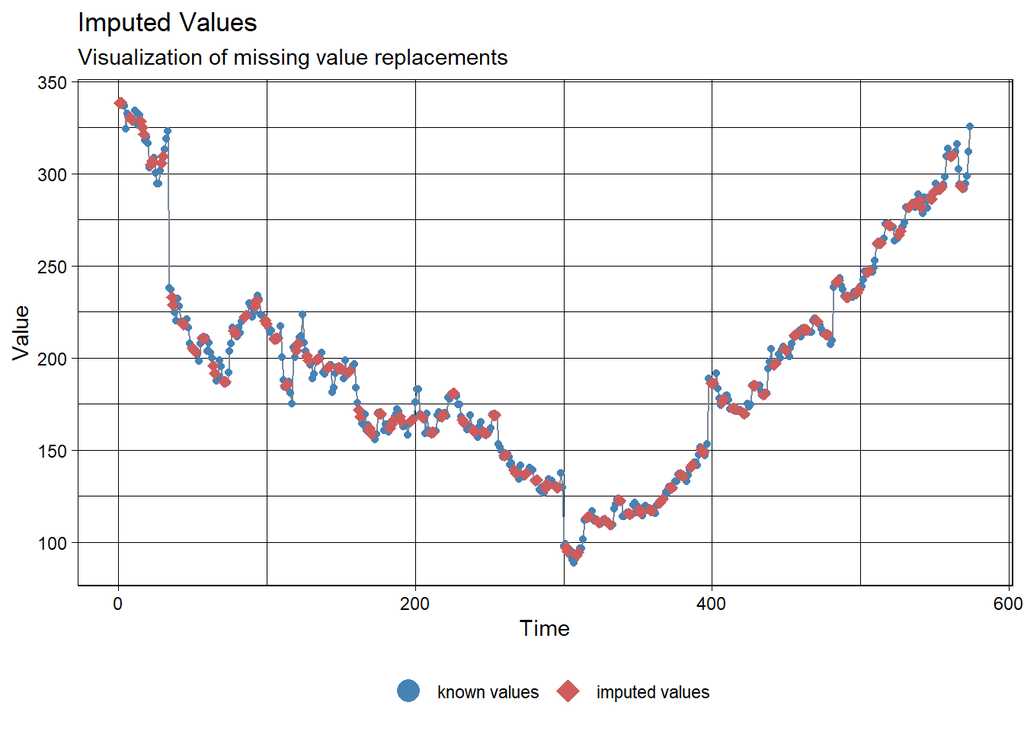

```r
#Tanggal diubah ke format tanggal
meta$Date <-as.Date(meta$Date, format="%Y-%m-%d")

#Buat tanggal penuh termasuk hari libur dan weekend
ihsgdates<-data.frame(Date=seq(as.Date("2022-01-01"), as.Date("2023-07-28"), by="days"))

#Gabungin data tanggal yang penuh dan yang missing value
meta <-merge(ihsgdates, meta, by="Date", all.x=TRUE)

#Imputasi data
meta$fixed <-na_interpolation(meta$Adj.Close)
ggplot_na_imputations(meta$Adj.Close, meta$fixed)
```

```r
meta <- meta[,-3]
colnames (meta) [ colnames (meta)  ==  "fixed" ]  <-  "Adj.Close"
dim(meta)
```

```
## [1] 574   3
```

## Time Series

```r
meta.ts <- ts(meta$Adj.Close)
summary(meta.ts)
```

```
##    Min. 1st Qu.  Median    Mean 3rd Qu.    Max.
##   88.91  157.08  187.38  194.99  222.99  338.54
```

```r
min_value <- min(meta$`Adj.Close`)
min_date <- meta$Date[which.min(meta$`Adj.Close`)]
percentage <- (which.min(meta$`Adj.Close`) / nrow(meta)) * 100

ggplot(meta, aes(x=Date, y=`Adj.Close`)) +
  geom_line(aes(color=Name), linewidth=2) +
  scale_color_manual(values = c("blue")) +
  labs(x = "\nPeriode (Tahun)", y='Saham Harga penutup',
       title = "Time Series Saham") +
  theme(legend.position = "none") +
  theme +
  geom_vline(xintercept = as.numeric(min_date),
             linetype = "dotted", color = "black", linewidth = 1.5) +
  geom_text(aes(x = min_date-1*40, y = max(`Adj.Close`)*80/100, label =
                  paste0("Titik Terendah\n","(",round(percentage, 2), "%)",
                         "   ",min_date)),
            vjust = -1.5, hjust = 0, size = 10, color = "black")
```

[figure not shown]

## **Pembagian Data Training Dan Test**

membagi 80% data latih (training) dan 20% data uji (testing)

```r
train <- meta[1: round(nrow(meta) *80/100),]
test <- meta[round(nrow(meta) *80/100 +1): nrow(meta),]
train.ts <- ts(train[,3])
test.ts <- ts(test[,3])
```

## Plot Data Time Series

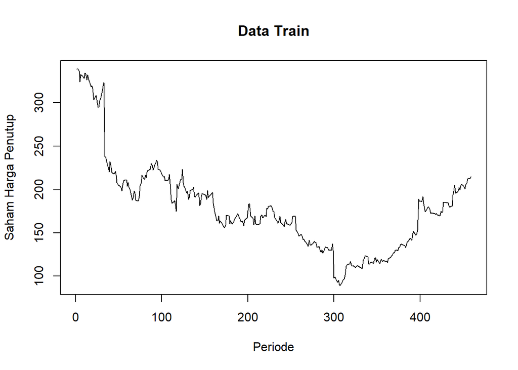

```r
#Plot data train
ts.plot(train.ts, xlab="Periode", ylab="Saham Harga Penutup", lty=1)
title("Data Train")
```

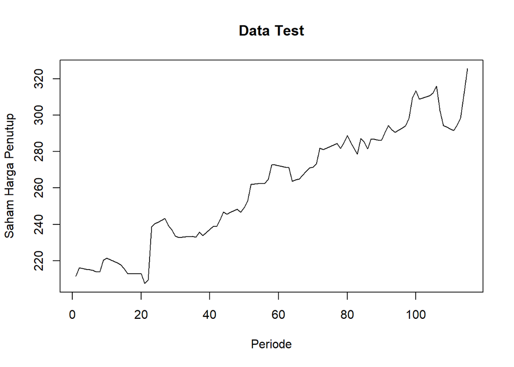

```r
#Plot data test
ts.plot(test.ts, xlab="Periode", ylab="Saham Harga Penutup", lty=1)
title("Data Test")
```

```r
ggplot() +
  geom_line(data = train, linewidth=2,
            aes(x = Date, y = `Adj.Close`, col = "Data Latih")) +
  geom_line(data = test, linewidth=2,
            aes(x = Date, y = `Adj.Close`, col = "Data Uji")) +
  labs(x = "\nPeriode (Tahun)", y='Saham Harga penutup',
       title = "Time Series Saham",
       subtitle = "Pembagian Data Training dan Test\n") +
  theme(legend.position = "none") +
  scale_colour_manual(name="Keterangan:",
                      breaks = c("Data Latih", "Data Uji"),
                      values = c("blue", "black")) + theme
```

[figure not shown]

Dari visualisasi grafik deret waktu pada data latih ($80\%$ dari data asli), terlihat bahwa data menunjukkan adanya tren turun dan tren naik. Hal ini menunjukkan bahwa data latih tidak memenuhi kriteria stasioneritas dalam rataan maupun ragam. Sementara itu, dalam plot data uji ($20\%$ dari data asli), tampaknya terdapat tren kenaikan yang signifikan dan ketiadaan nilai tengah yang stabil. Hal ini juga menandakan bahwa data uji tidak memenuhi persyaratan stasioneritas dalam rataan.

# UJI STASIONER DATA

## Plot ACF

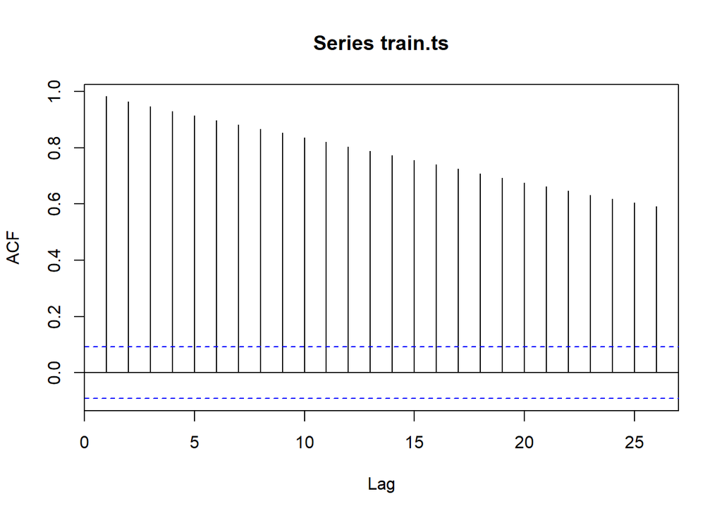

```r
acf(train.ts)
```

Berdasarkan plot ACF, terlihat bahwa plot ACF data train menurun secara perlahan. Hal ini menjadi indikasi bahwa data tidak stasioner dalam rataan dan tidak membentuk gelombang sinus.

## Uji ADF

```r
tseries::adf.test(train.ts)
```

```
##
##  Augmented Dickey-Fuller Test
##
## data:  train.ts
## Dickey-Fuller = -1.6176, Lag order = 7, p-value = 0.7396
## alternative hypothesis: stationary
```

> $H_0$ : Data tidak stasioner dalam rataan

> $H_1$ : Data stasioner dalam rataan

## Plot Box-Cox

```r
index <- seq(1:nrow(meta))
bc = boxcox(meta.ts~index, lambda = seq(-2, 4, by=0.01))
```

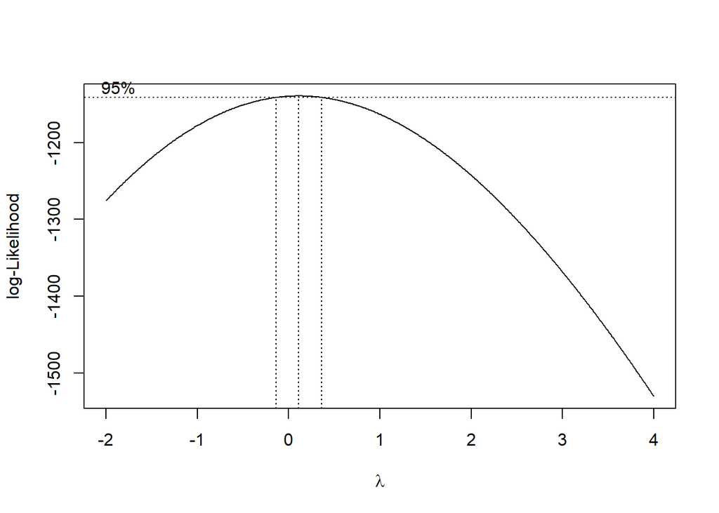

```r
#Nilai Rounded Lambda
lambda <- bc$x[which.max(bc$y)]
#SK
sk_meta <- bc$x[bc$y > max(bc$y) - 1/2 * qchisq(.95,1)]
cat(" Lambda :", lambda,
    "\n\n Selang Kepercyaan 95% \n",
    "Batas Bawah :", min(sk_meta), "\n Batas Atas  :", max(sk_meta) )
```

```
##  Lambda : 0.11
##
##  Selang Kepercyaan 95%
##  Batas Bawah : -0.13
##  Batas Atas  : 0.36
```

# **Penanganan Ketidakstasioneran**

## Differencing

```r
diff.train <- diff(train.ts, differences = 1)
plot.ts(diff.train, lty=1, xlab="Periode (Tahun)",
        col = "dodgerblue3", lwd = 3.5,
        main="Plot Difference Saham META")
```

[figure not shown]

Berdasarkan plot tersebut, terlihat bahwa plot sudah stasioner dalam rataan dan tidak memiliki pola musiman

### Uji Lanjutan

#### Plot ACF

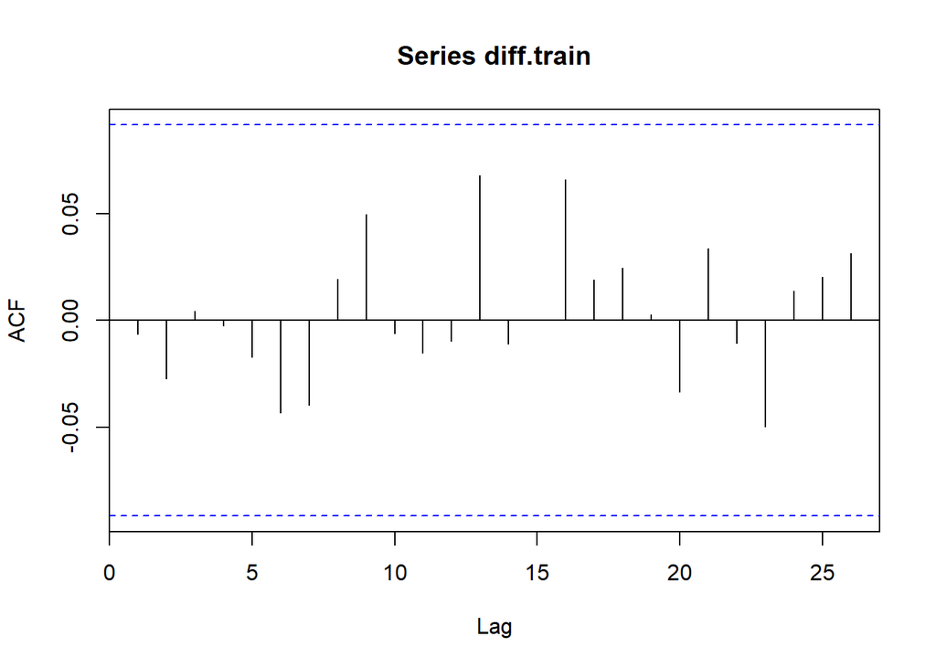

```r
acf(diff.train)
```

#### Uji ADF

```r
tseries::adf.test(diff.train)
```

```
##
##  Augmented Dickey-Fuller Test
##
## data:  diff.train
## Dickey-Fuller = -8.5334, Lag order = 7, p-value = 0.01
## alternative hypothesis: stationary
```

> $H_0$ : Data tidak stasioner dalam rataan

> $H_1$ : Data stasioner dalam rataan

Berdasarkan uji ADF tersebut, didapat *p-value* sebesar $0.01$ yang lebih kecil dari taraf nyata $5\%$ sehingga **tolak** $H_0$ atau data stasioner dalam rataan.

Hal ini sesuai dengan hasil eksplorasi menggunakan plot time series dan plot ACF, sehingga dalam hal ini ketidakstasioneran data sudah berhasil ditangani dan dapat dilanjutkan ke pemodelan.

## Transformasi Box Cox

```r
boxcox.train <- forecast::BoxCox(train.ts, lambda)
plot.ts(boxcox.train, lty=1, xlab="Periode (Tahun)",
        col = "dodgerblue3", lwd = 3.5,
        main="Plot Transformasi Boxcox Saham META")
```

[figure not shown]

```r
boxcox.train1 <- forecast::BoxCox(train.ts, lambda = -2)
boxcox.train2 <- forecast::BoxCox(train.ts, lambda = -1)
boxcox.train3 <- forecast::BoxCox(train.ts, lambda = -0.5)
boxcox.train4 <- forecast::BoxCox(train.ts, lambda = 0)
boxcox.train5 <- forecast::BoxCox(train.ts, lambda = 0.5)
boxcox.train6 <- forecast::BoxCox(train.ts, lambda = 1)
boxcox.train7 <- forecast::BoxCox(train.ts, lambda = 2)
```

### Uji Lanjutan

#### Plot ACF

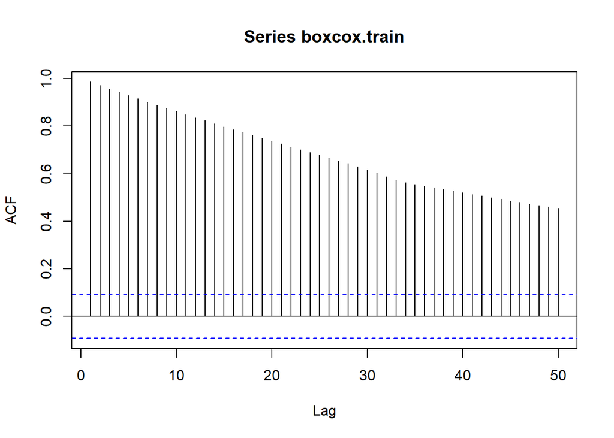

```r
acf(boxcox.train,lag.max = 50)
```

#### Uji ADF

```r
tseries::adf.test(boxcox.train)
```

```
##
##  Augmented Dickey-Fuller Test
##
## data:  boxcox.train
## Dickey-Fuller = -1.0767, Lag order = 7, p-value = 0.9261
## alternative hypothesis: stationary
```

```r
#Lainya
tseries::adf.test(boxcox.train1)
```

```
##
##  Augmented Dickey-Fuller Test
##
## data:  boxcox.train1
## Dickey-Fuller = -1.817, Lag order = 7, p-value = 0.6553
## alternative hypothesis: stationary
```

```r
tseries::adf.test(boxcox.train2)
```

```
##
##  Augmented Dickey-Fuller Test
##
## data:  boxcox.train2
## Dickey-Fuller = -1.2367, Lag order = 7, p-value = 0.9003
## alternative hypothesis: stationary
```

```r
tseries::adf.test(boxcox.train3)
```

```
##
##  Augmented Dickey-Fuller Test
##
## data:  boxcox.train3
## Dickey-Fuller = -1.0668, Lag order = 7, p-value = 0.9277
## alternative hypothesis: stationary
```

```r
tseries::adf.test(boxcox.train4)
```

```
##
##  Augmented Dickey-Fuller Test
##
## data:  boxcox.train4
## Dickey-Fuller = -1.0536, Lag order = 7, p-value = 0.9298
## alternative hypothesis: stationary
```

```r
tseries::adf.test(boxcox.train5)
```

```
##
##  Augmented Dickey-Fuller Test
##
## data:  boxcox.train5
## Dickey-Fuller = -1.2396, Lag order = 7, p-value = 0.8995
## alternative hypothesis: stationary
```

```r
tseries::adf.test(boxcox.train6)
```

```
##
##  Augmented Dickey-Fuller Test
##
## data:  boxcox.train6
## Dickey-Fuller = -1.6176, Lag order = 7, p-value = 0.7396
## alternative hypothesis: stationary
```

```r
tseries::adf.test(boxcox.train7)
```

```
##
##  Augmented Dickey-Fuller Test
##
## data:  boxcox.train7
## Dickey-Fuller = -2.6944, Lag order = 7, p-value = 0.2842
## alternative hypothesis: stationary
```

> $H_0$ : Data tidak stasioner dalam rataan

> $H_1$ : Data stasioner dalam rataan

Berdasarkan uji ADF tersebut, didapat *p-value* lebih besar dari taraf nyata $5\%$ sehingga **terima** $H_0$ atau data tidak stasioner dalam rataan.

Hal ini sesuai dengan hasil eksplorasi menggunakan plot time series dan plot ACF, sehingga dalam hal ini ketidakstasioneran data tidak berhasil ditangani dan dapat dilanjutkan ke pemodelan.

# IDENTIFIKASI MODEL

## Plot ACF

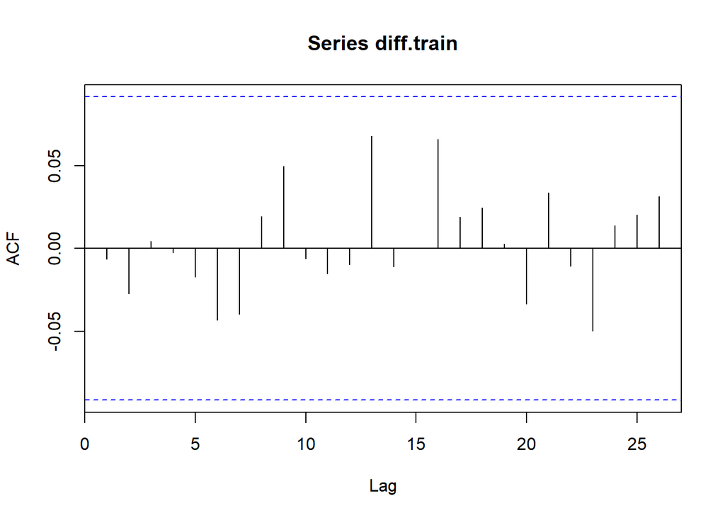

```r
acf(diff.train)
```

## Plot PACF

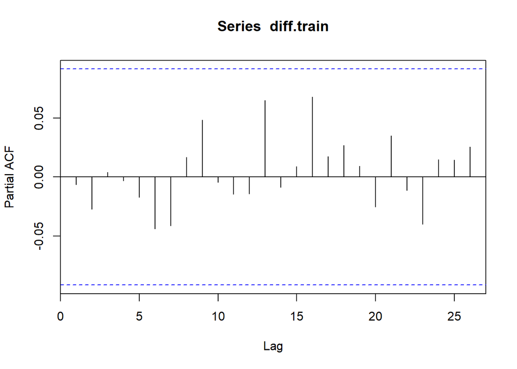

```r
pacf(diff.train)
```

## Plot EACF

```r
eacf(diff.train)
```

```
## AR/MA
##   0 1 2 3 4 5 6 7 8 9 10 11 12 13
## 0 o o o o o o o o o o o  o  o  o
## 1 x o o o o o o o o o o  o  o  o
## 2 x o o o o o o o o o o  o  o  o
## 3 x o o o o o o o o o o  o  o  o
## 4 x x o o o o o o o o o  o  o  o
## 5 x o x o x o o o o o o  o  o  o
## 6 x x x o o o o o o o o  o  o  o
## 7 x x x o o o x o o o o  o  o  o
```

Identifikasi model menggunakan plot EACF dilakukan dengan melihat titik sudut kiri segitiga pada pola segitiga nol atas (pola mariks segitiga bawah). Dalam hal ini model tentatif yang terbentuk adalah ARIMA(0,1,1), ARIMA(1,1,1), ARIMA(2,1,2), ARIMA(3,1,3), dst..

## Model tanpa intersep dan drift

```r
model01 <-  model1(train.ts, p_max = 6, d = 1, q_max = 12)
```

```
## AR/MA
##   0 1 2 3 4 5 6 7 8 9 10 11 12 13
## 0 x x x x x x x x x x x  x  x  x
## 1 o o o o o o o o o o o  o  o  o
## 2 x o o o o o o o o o o  o  o  o
## 3 o x o o o o o o o o o  o  o  o
## 4 x o o o o o o o o o o  o  o  o
## 5 x x o o o o o o o o o  o  o  o
## 6 x o x o x o o o o o o  o  o  o
## 7 x x x o o o o o o o o  o  o  o
##
## Model ARIMA dengan AIC terkecil:
## NULL
```

```r
head(model01)
```

```
##          Model      AIC         Signif
## 1 ARIMA(1,1,1) 2998.458         NA, NA
## 2 ARIMA(1,1,2) 3000.162
## 3 ARIMA(1,1,3) 3002.148
## 4 ARIMA(1,1,4) 3004.144 NA, NA, NA, NA
## 5 ARIMA(1,1,5) 3005.575
## 6 ARIMA(1,1,6) 3007.042
##                                                   Keterangan
## 1                                 Semua parameter signifikan
## 2                           Semua parameter tidak signifikan
## 3                           Semua parameter tidak signifikan
## 4 Parameter yang tidak signifikan adalah NA, NA, ma2, NA, NA
## 5                           Semua parameter tidak signifikan
## 6                           Semua parameter tidak signifikan
```

## Model dengan intersep tanpa drift

```r
model02 <-  model1(diff.train, p_max = 6, d = 1, q_max = 12)
```

```
## AR/MA
##   0 1 2 3 4 5 6 7 8 9 10 11 12 13
## 0 o o o o o o o o o o o  o  o  o
## 1 x o o o o o o o o o o  o  o  o
## 2 x o o o o o o o o o o  o  o  o
## 3 x o o o o o o o o o o  o  o  o
## 4 x x o o o o o o o o o  o  o  o
## 5 x o x o x o o o o o o  o  o  o
## 6 x x x o o o o o o o o  o  o  o
## 7 x x x o o o x o o o o  o  o  o
##
## Model ARIMA dengan AIC terkecil:
## Series: data
## ARIMA(0,1,1)
##
## Coefficients:
##           ma1
##       -0.9894
## s.e.   0.0070
##
## sigma^2 = 40.39:  log likelihood = -1494.99
## AIC=2993.99   AICc=2994.01   BIC=3002.24
```

```r
head(model02)
```

```
##          Model      AIC Signif
## 1 ARIMA(0,1,1) 2993.988    ma1
## 2 ARIMA(0,1,2) 2995.876    ma1
## 3 ARIMA(0,1,3) 2997.239    ma1
## 4 ARIMA(0,1,4) 2999.208    ma1
## 5 ARIMA(0,1,5) 3001.064    ma1
## 6 ARIMA(0,1,6) 3002.572    ma1
##                                                       Keterangan
## 1                                     Semua parameter signifikan
## 2                     Parameter yang tidak signifikan adalah ma2
## 3                Parameter yang tidak signifikan adalah ma2, ma3
## 4           Parameter yang tidak signifikan adalah ma2, ma3, ma4
## 5      Parameter yang tidak signifikan adalah ma2, ma3, ma4, ma5
## 6 Parameter yang tidak signifikan adalah ma2, ma3, ma4, ma5, ma6
```

## Model dengan drift tanpa intersep

```r
model03 <-  model2(train.ts, p_max = 6, d = 1, q_max = 12)
```

```
## AR/MA
##   0 1 2 3 4 5 6 7 8 9 10 11 12 13
## 0 x x x x x x x x x x x  x  x  x
## 1 o o o o o o o o o o o  o  o  o
## 2 x o o o o o o o o o o  o  o  o
## 3 o x o o o o o o o o o  o  o  o
## 4 x o o o o o o o o o o  o  o  o
## 5 x x o o o o o o o o o  o  o  o
## 6 x o x o x o o o o o o  o  o  o
## 7 x x x o o o o o o o o  o  o  o
##
## Model ARIMA dengan AIC terkecil:
## NULL
```

```r
head(model03)
```

```
##          Model      AIC Signif
## 1 ARIMA(1,1,1) 2999.616 NA, NA
## 2 ARIMA(1,1,2) 3001.272
## 3 ARIMA(1,1,3) 3003.267
## 4 ARIMA(1,1,4) 3005.257 NA, NA
## 5 ARIMA(1,1,5) 3006.568
## 6 ARIMA(1,1,6) 3008.007
##                                                            Keterangan
## 1                Parameter yang tidak signifikan adalah NA, NA, drift
## 2                                    Semua parameter tidak signifikan
## 3                                    Semua parameter tidak signifikan
## 4 Parameter yang tidak signifikan adalah NA, NA, ma2, ma3, ma4, drift
## 5                                    Semua parameter tidak signifikan
## 6                                    Semua parameter tidak signifikan
```

## Model dengan intersep dan drift

```r
model04 <-  model2(diff.train, p_max = 6, d = 1, q_max = 12)
```

```
## AR/MA
##   0 1 2 3 4 5 6 7 8 9 10 11 12 13
## 0 o o o o o o o o o o o  o  o  o
## 1 x o o o o o o o o o o  o  o  o
## 2 x o o o o o o o o o o  o  o  o
## 3 x o o o o o o o o o o  o  o  o
## 4 x x o o o o o o o o o  o  o  o
## 5 x o x o x o o o o o o  o  o  o
## 6 x x x o o o o o o o o  o  o  o
## 7 x x x o o o x o o o o  o  o  o
##
## Model ARIMA dengan AIC terkecil:
## Series: data
## ARIMA(0,1,1) with drift
##
## Coefficients:
##           ma1   drift
##       -1.0000  0.0056
## s.e.   0.0061  0.0022
##
## sigma^2 = 39.92:  log likelihood = -1492.95
## AIC=2991.9   AICc=2991.95   BIC=3004.28
```

```r
head(model04)
```

```
##          Model      AIC     Signif
## 1 ARIMA(0,1,1) 2991.902 ma1, drift
## 2 ARIMA(0,1,2) 2993.734 ma1, drift
## 3 ARIMA(0,1,3) 2994.977 ma1, drift
## 4 ARIMA(0,1,4) 2996.914 ma1, drift
## 5 ARIMA(0,1,5) 2998.705 ma1, drift
## 6 ARIMA(0,1,6) 3000.125 ma1, drift
##                                                       Keterangan
## 1                                     Semua parameter signifikan
## 2                     Parameter yang tidak signifikan adalah ma2
## 3                Parameter yang tidak signifikan adalah ma2, ma3
## 4           Parameter yang tidak signifikan adalah ma2, ma3, ma4
## 5      Parameter yang tidak signifikan adalah ma2, ma3, ma4, ma5
## 6 Parameter yang tidak signifikan adalah ma2, ma3, ma4, ma5, ma6
```

## Model Terpilih

```r
#Model tanpa intersep dan drift tidak Ada

#Model tanpa intersep dan drift
bestmodel1 <- Arima(diff.train, order=c(0,1,1), method="ML")

#Model dengan drift tanpa intersep Tidak Ada

#Model dengan intersep dan drift
bestmodel2 <- Arima(diff.train, order=c(0,1,1), include.drift=TRUE)
```

# DIAGNOSTIK SISAAN DAN EKPLORASI

## ARIMA(0,1,1)

### Ekplorasi

```r
bestmodel1 <- Arima(diff.train, order=c(0,1,1), method="ML")
sisaan01 <- bestmodel1$residuals
par(mfrow=c(2,2))
#QQPlot
qqnorm(sisaan01)
qqline(sisaan01 , col = "blue", lwd = 2)

#Plot
plot(c(1:length(sisaan01)), sisaan01,
     main = "Plot Sisaan Model ARIMA",
     xlab = "Periode",
     ylab = "Nilai Sisaan")
abline(h = 0, col = "red", lty = 2, lwd=2.5)

#Plot ACF dan PACF
acf(sisaan01)
pacf(sisaan01)
```

[figure not shown]

Berdasarkan plot kuantil-kuantil normal, secara eksplorasi ditunjukkan sisaan **tidak menyebar normal** ditandai dengan tidak semua titik mengikuti garis $45^{\circ}$.

Kemudian dapat dilihat juga lebar pita sisaan yang cenderung tidak sama menandakan bahwa sisaan memiliki ragam yang **tidak homogen**.

### Uji Formal

#### Uji Normalitas

```r
nortest::ad.test(sisaan01)
```

```
##
##  Anderson-Darling normality test
##
## data:  sisaan01
## A = 28.786, p-value < 2.2e-16
```

```r
jarque.bera.test(sisaan01)
```

```
##
##  Jarque Bera Test
##
## data:  sisaan01
## X-squared = 99991, df = 2, p-value < 2.2e-16
```

```r
shapiro.test(sisaan01)
```

```
##
##  Shapiro-Wilk normality test
##
## data:  sisaan01
## W = 0.64399, p-value < 2.2e-16
```

> $H_0$ : Sisaan menyebar normal

> $H_1$ : Sisaan tidak menyebar normal

#### Uji Kebebasan

```r
Box.test(sisaan01 , type = "Ljung")
```

```
##
##  Box-Ljung test
##
## data:  sisaan01
## X-squared = 0.20819, df = 1, p-value = 0.6482
```

> $H_0$ : Sisaan saling bebas

> $H_1$ : Sisaan tidak tidak saling bebas

Berdasarkan uji Ljung-Box tersebut, didapat *p-value* sebesar $0.6482$ yang lebih besar dari taraf nyata $5\%$ sehingga **tak tolak** $H_0$ dan menandakan bahwa **sisaan saling bebas**.

#### Sisaan Homogen

```r
Box.test((sisaan01)^2 , type = "Ljung")
```

```
##
##  Box-Ljung test
##
## data:  (sisaan01)^2
## X-squared = 0.0064456, df = 1, p-value = 0.936
```

Hipotesis yang digunakan untuk uji kehomogenan ragam adalah sebagai berikut.

> $H_0$ : Ragam sisaan homogen

> $H_1$ : Ragam sisaan tidak homogen

Berdasarkan uji Ljung-Box terhadap sisaan kuadrat tersebut, didapat *p-value* sebesar $0.936$ yang lebih besar dari taraf nyata $5\%$ sehingga **tak tolak** $H_0$ dan menandakan bahwa **ragam sisaan homogen**.

#### Uji Nilai tengah sisaan sama dengan nol

```r
t.test(sisaan01, mu = 0, conf.level = 0.95)
```

```
##
##  One Sample t-test
##
## data:  sisaan01
## t = 1.446, df = 457, p-value = 0.1489
## alternative hypothesis: true mean is not equal to 0
## 95 percent confidence interval:
##  -0.1536368  1.0095515
## sample estimates:
## mean of x
## 0.4279574
```

Terakhir, dengan uji-t, akan dicek apakah nilai tengah sisaan sama dengan nol. Hipotesis yang diujikan sebagai berikut.

> $H_0$ : nilai tengah sisaan sama dengan 0

> $H_1$ : nilai tengah sisaan tidak sama dengan 0

Berdasarkan uji-ttersebut, didapat *p-value* sebesar $0.1489$ yang lebih besar dari taraf nyata $5\%$ sehingga **tak tolak** $H_0$ dan menandakan bahwa **nilai tengah sisaan sama dengan nol.**

## ARIMA(0,1,1) With Drift

### Ekplorasi

```r
bestmodel2 <- Arima(diff.train, order=c(0,1,1), include.drift=TRUE)
sisaan02 <- bestmodel2$residuals
par(mfrow=c(2,2))
#QQPlot
qqnorm(sisaan02)
qqline(sisaan02 , col = "blue", lwd = 2)

#Plot
plot(c(1:length(sisaan02)), sisaan02,
     main = "Plot Sisaan Model ARIMA",
     xlab = "Periode",
     ylab = "Nilai Sisaan")
abline(h = 0, col = "red", lty = 2, lwd=2.5)

#Plot ACF dan PACF
acf(sisaan02)
pacf(sisaan02)
```

[figure not shown]

Berdasarkan plot kuantil-kuantil normal, secara eksplorasi ditunjukkan sisaan **tidak menyebar normal** ditandai dengan tidak semua titik mengikuti garis $45^{\circ}$.

Kemudian dapat dilihat juga lebar pita sisaan yang cenderung tidak sama menandakan bahwa sisaan memiliki ragam yang **tidak homogen**.

### Uji Formal

#### Uji Normalitas

```r
nortest::ad.test(sisaan02)
```

```
##
##  Anderson-Darling normality test
##
## data:  sisaan02
## A = 28.373, p-value < 2.2e-16
```

```r
jarque.bera.test(sisaan02)
```

```
##
##  Jarque Bera Test
##
## data:  sisaan02
## X-squared = 97294, df = 2, p-value < 2.2e-16
```

```r
shapiro.test(sisaan02)
```

```
##
##  Shapiro-Wilk normality test
##
## data:  sisaan02
## W = 0.64664, p-value < 2.2e-16
```

> $H_0$ : Sisaan menyebar normal

> $H_1$ : Sisaan tidak menyebar normal

#### Uji Kebebasan

```r
Box.test(sisaan02 , type = "Ljung")
```

```
##
##  Box-Ljung test
##
## data:  sisaan02
## X-squared = 0.18474, df = 1, p-value = 0.6673
```

> $H_0$ : Sisaan saling bebas

> $H_1$ : Sisaan tidak tidak saling bebas

Berdasarkan uji Ljung-Box tersebut, didapat *p-value* sebesar $0.6673$ yang lebih besar dari taraf nyata $5\%$ sehingga **tak tolak** $H_0$ dan menandakan bahwa **sisaan saling bebas**.

#### Sisaan Homogen

```r
Box.test((sisaan02)^2 , type = "Ljung")
```

```
##
##  Box-Ljung test
##
## data:  (sisaan02)^2
## X-squared = 0.006313, df = 1, p-value = 0.9367
```

Hipotesis yang digunakan untuk uji kehomogenan ragam adalah sebagai berikut.

> $H_0$ : Ragam sisaan homogen

> $H_1$ : Ragam sisaan tidak homogen

Berdasarkan uji Ljung-Box terhadap sisaan kuadrat tersebut, didapat *p-value* sebesar $0.9367$ yang lebih besar dari taraf nyata $5\%$ sehingga **tak tolak** $H_0$ dan menandakan bahwa **ragam sisaan homogen**.

#### Uji Nilai tengah sisaan sama dengan nol

```r
t.test(sisaan02, mu = 0, conf.level = 0.95)
```

```
##
##  One Sample t-test
##
## data:  sisaan02
## t = 0.13836, df = 457, p-value = 0.89
## alternative hypothesis: true mean is not equal to 0
## 95 percent confidence interval:
##  -0.5381196  0.6196308
## sample estimates:
##  mean of x
## 0.04075562
```

Terakhir, dengan uji-t, akan dicek apakah nilai tengah sisaan sama dengan nol. Hipotesis yang diujikan sebagai berikut.

> $H_0$ : nilai tengah sisaan sama dengan 0

> $H_1$ : nilai tengah sisaan tidak sama dengan 0

Berdasarkan uji-ttersebut, didapat *p-value* sebesar $0.89$ yang lebih besar dari taraf nyata $5\%$ sehingga **tak tolak** $H_0$ dan menandakan bahwa **nilai tengah sisaan sama dengan nol.**

# Overfitting

Tahapan selanjutnya adalah *overfitting* dilakukan dengan menaikkan orde AR(p) dan MA(q) dari model ARIMA(0,1,1) untuk melihat apakah terdapat model lain yang lebih baik dari model saat ini. Kandidat model *overfitting* adalah ARIMA(0,1,2) dan ARIMA(0,1,3).

```r
# ARIMA(0,1,1)
model3=Arima(diff.train, order=c(0,1,2),method="ML")
summary(model3)
```

```
## Series: diff.train
## ARIMA(0,1,2)
##
## Coefficients:
##           ma1     ma2
##       -1.0056  0.0163
## s.e.   0.0486  0.0485
##
## sigma^2 = 40.47:  log likelihood = -1494.94
## AIC=2995.88   AICc=2995.93   BIC=3008.25
##
## Training set error measures:
##                     ME     RMSE    MAE      MPE     MAPE      MASE         ACF1
## Training set 0.4277449 6.340366 3.2498 140.1114 180.1539 0.7274377 -0.005594057
```

```r
lmtest::coeftest(model3)
```

```
##
## z test of coefficients:
##
##      Estimate Std. Error  z value Pr(>|z|)
## ma1 -1.005591   0.048580 -20.6995   <2e-16 ***
## ma2  0.016283   0.048454   0.3361   0.7368
## ---
## Signif. codes:  0 '***' 0.001 '**' 0.01 '*' 0.05 '.' 0.1 ' ' 1
```

```r
# ARIMA(0,1,3)
model4=Arima(diff.train, order=c(0,1,3),method="ML")
summary(model4)
```

```
## Series: diff.train
## ARIMA(0,1,3)
##
## Coefficients:
##           ma1      ma2     ma3
##       -1.0055  -0.0213  0.0378
## s.e.   0.0468   0.0662  0.0475
##
## sigma^2 = 40.5:  log likelihood = -1494.62
## AIC=2997.24   AICc=2997.33   BIC=3013.74
##
## Training set error measures:
##                     ME     RMSE      MAE     MPE     MAPE     MASE         ACF1
## Training set 0.4280919 6.335848 3.269985 133.211 178.2437 0.731956 -0.005963143
```

```r
lmtest::coeftest(model4)
```

```
##
## z test of coefficients:
##
##      Estimate Std. Error  z value Pr(>|z|)
## ma1 -1.005509   0.046794 -21.4881   <2e-16 ***
## ma2 -0.021325   0.066201  -0.3221   0.7474
## ma3  0.037819   0.047503   0.7962   0.4259
## ---
## Signif. codes:  0 '***' 0.001 '**' 0.01 '*' 0.05 '.' 0.1 ' ' 1
```

Berdasarkan kedua model hasil *overfitting* di atas, model ARIMA(0,1,2) dan ARIMA(0,1,3) memiliki AIC yang lebih besar dan tidak seluruhnya signifikan. Oleh karena itu, model ARIMA(0,1,1) akan tetap digunakan untuk melakukan peramalan.

# Forecasting

Peramalan dilakukan untuk 115 periode ke depan.

```r
ramalan<- forecast::forecast(bestmodel1, h = 0.2*574)
ramalan
```

```
##     Point Forecast     Lo 80    Hi 80     Lo 95    Hi 95
## 460      0.5291524 -7.615196 8.673501 -11.92655 12.98486
## 461      0.5291524 -7.615650 8.673955 -11.92725 12.98555
## 462      0.5291524 -7.616104 8.674408 -11.92794 12.98625
## 463      0.5291524 -7.616557 8.674862 -11.92864 12.98694
## 464      0.5291524 -7.617011 8.675316 -11.92933 12.98763
## 465      0.5291524 -7.617465 8.675770 -11.93002 12.98833
## 466      0.5291524 -7.617919 8.676224 -11.93072 12.98902
## 467      0.5291524 -7.618373 8.676677 -11.93141 12.98972
## 468      0.5291524 -7.618826 8.677131 -11.93211 12.99041
## 469      0.5291524 -7.619280 8.677585 -11.93280 12.99110
## 470      0.5291524 -7.619734 8.678039 -11.93349 12.99180
## 471      0.5291524 -7.620187 8.678492 -11.93419 12.99249
## 472      0.5291524 -7.620641 8.678946 -11.93488 12.99319
## 473      0.5291524 -7.621095 8.679399 -11.93557 12.99388
```

[output cut: 100 more lines]

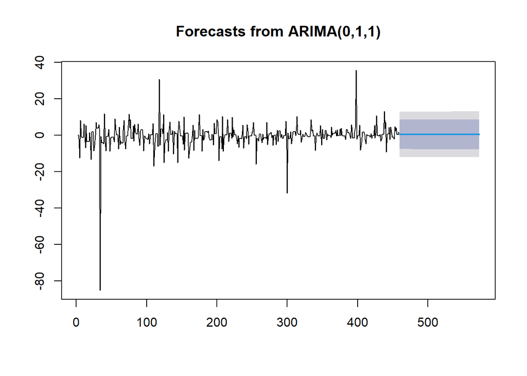

```r
data.ramalan <- ramalan$mean
plot(ramalan)
```

# Akurasi

```r
pt_1 <- train.ts[length(train.ts)]
hasil <- data.ramalan
ramal_meta <- diffinv(hasil, differences = 1) + pt_1

ts.plot(train.ts, ramal_meta, xlab="Periode (Hari)",
        col = "blue", lwd = 3,
        ylab="Saham Harga (USD)",
        main="Plot Ramalan Saham META Selama 115 Hari Kedepan")
```

[figure not shown]

```r
perbandingan<-matrix(data=c(head(test.ts, n=115), ramal_meta[-1]),
                     nrow = 115, ncol = 2)
colnames(perbandingan)<-c("Aktual","Hasil Forecast")
perbandingan
```

```
##          Aktual Hasil Forecast
##   [1,] 211.4800       215.2492
##   [2,] 216.1000       215.7783
##   [3,] 215.7625       216.3075
##   [4,] 215.4250       216.8366
##   [5,] 215.0875       217.3658
##   [6,] 214.7500       217.8949
##   [7,] 213.8500       218.4241
##   [8,] 214.0000       218.9532
##   [9,] 220.3500       219.4824
##  [10,] 221.4900       220.0115
##  [11,] 220.6133       220.5407
##  [12,] 219.7367       221.0698
##  [13,] 218.8600       221.5990
##  [14,] 217.8900       222.1281
```

[output cut: 101 more lines]

```r
accuracy(ts(ramal_meta[-1]), head(test.ts, n=115))
```

```
##                ME     RMSE     MAE      MPE     MAPE      ACF1 Theil's U
## Test set 14.97457 21.09282 17.2498 5.158503 6.228933 0.9401759  4.059981
```

Nilai MAPE yang diperoleh adalah $6.228%$. Artinya akurasi antara hasil ramalan terhadap data uji sangat baik.